# 03_Full_code_notebook_TSF_project

## Problem Statement

For this particular assignment, the data of different types of wine sales in the 20th century is to be analysed. Both of these data are from the same company but of different wines. As an analyst in the ABC Estate Wines, you are tasked to analyse and forecast Wine Sales in the 20th century.

## Index

- Import Libraries
- Loading Dataset
- Data Overview
- Exploratory Data Analysis (EDA)
- Data Preparation
- Model Builiding
- Model Comparison and Final Model Selection
- Forecast using Final Model
- Business Insights and Recommendations

## Importing necessary libraries

```python
# Ignore warnings
import warnings
warnings.filterwarnings('ignore')
from statsmodels.tools.sm_exceptions import ConvergenceWarning
warnings.simplefilter('ignore', ConvergenceWarning)

# Libraries to help with reading and manipulating data
import numpy as np
import pandas as pd

# Libraries to help with data visualization
import matplotlib.pyplot as plt
import seaborn as sns
%matplotlib inline

# Set pandas display options for better readability of output
from IPython.display import display
pd.set_option("display.max_columns", None)
pd.set_option("display.max_rows", 200)
pd.set_option("display.float_format", lambda x: "%.4f" % x)

# Set Seaborn aesthetic parameters
sns.set(
    context='notebook',
    style='darkgrid',
    #palette="Blues",
    font='sans-serif',
    font_scale=0.8,
    rc={'figure.figsize': (12, 6)}
)

# Time Series Analysis and Forecasting libraries
import statsmodels.api as sm
from statsmodels.tsa.arima.model import ARIMA as ar
from statsmodels.tsa.seasonal import seasonal_decompose
from sklearn.linear_model import LinearRegression
import statsmodels as st
from statsmodels.tsa.api import ExponentialSmoothing, SimpleExpSmoothing, Holt
from statsmodels.tsa.arima.model import ARIMA
import itertools
from statsmodels.graphics.tsaplots import plot_acf, plot_pacf
from statsmodels.tsa.stattools import adfuller

# Metrics for model evaluation
from sklearn import metrics
```

## Loading the dataset

```python
# Load Sparkling.csv dataset, parse dates using YearMonth column and sent YearMonth column as Index
datafilepath = 'Sparkling.csv'
df_sparkling = pd.read_csv(datafilepath)
```

```python
# Display top 5 records
df_sparkling.head()
```

|  | YearMonth | Sparkling |
| --- | --- | --- |
| 0 | 1980-01 | 1686 |
| 1 | 1980-02 | 1591 |
| 2 | 1980-03 | 2304 |
| 3 | 1980-04 | 1712 |
| 4 | 1980-05 | 1471 |

```python
# Display last 5 records
df_sparkling.tail()
```

|  | YearMonth | Sparkling |
| --- | --- | --- |
| 182 | 1995-03 | 1897 |
| 183 | 1995-04 | 1862 |
| 184 | 1995-05 | 1670 |
| 185 | 1995-06 | 1688 |
| 186 | 1995-07 | 2031 |

## Data Overview

```python
# Display Shape of the Dataset
print(f'The dataset has {df_sparkling.shape[0]} observations and {df_sparkling.shape[1]} features')
```

```
The dataset has 187 observations and 2 features
```

```python
# Display Dataset Information
df_sparkling.info()
```

```
<class 'pandas.core.frame.DataFrame'>
RangeIndex: 187 entries, 0 to 186
Data columns (total 2 columns):
 #   Column     Non-Null Count  Dtype
---  ------     --------------  -----
 0   YearMonth  187 non-null    object
 1   Sparkling  187 non-null    int64
dtypes: int64(1), object(1)
memory usage: 3.1+ KB
```

- Dataset has 1 categorical and 1 numerical column.

```python
# Display Dataset Statistics
df_sparkling.describe().T
```

|  | count | mean | std | min | 25% | 50% | 75% | max |
| --- | --- | --- | --- | --- | --- | --- | --- | --- |
| Sparkling | 187.0000 | 2402.4171 | 1295.1115 | 1070.0000 | 1605.0000 | 1874.0000 | 2549.0000 | 7242.0000 |

- Sparkling sales shows average sales of 2,400, with minimum of 1,070 and maximum of 7,242.
- Variance in the sales suggest outliers.

```python
# Check for Missing Values
df_sparkling.isnull().sum()
```

```
YearMonth    0
Sparkling    0
dtype: int64
```

- There are no missing values in the dataset.

```python
# Check for Duplicates
df_sparkling.duplicated().sum()
```

```
0
```

- There are no duplicate values in the dataset.

### Dataset Observations:

- There are 2 columns with 187 data points.
- The mean sales value is 2402.42 with minimum value of 1070 and maximum value of 7242, shows diverse sales across the periods.
- Checks suggests no missing or duplicate values.
- Data provided include Monthly Sales for Sparkling wines between Jan-1980 to July-1995.

## Exploratory Data Analysis (EDA)

- Datetime column and Setting Index
- Univariate Analysis
  - Sparkling Sales Statistics
  - Sales Distribution Plot
  - Year and Month Statistics
- Bivariate Analysis
  - Time Plot
  - Pivot Table and Chart - Sales Trend by Month
  - Pivot Table and Chart - Sales Trend by Year
  - Seasonal Subseries Box Plot
  - Year-on-Year Trend and Outlier Detection Box Plot
  - Moving Average Chart
- Decomposition
  - Test for Additive Decomposition Assumption
  - Test for Multiplicative Decomposition Assumption
- EDA Observations

### Datetime column and Setting Index

```python
# Before starting with EDA we will convert YearMonth column to datetime
df_sparkling['YearMonthDate'] = pd.date_range(start='1980-01-01',periods=len(df_sparkling),freq='M')
df_sparkling.set_index('YearMonthDate', inplace=True)
df_sparkling.head()
```

| YearMonthDate | YearMonth | Sparkling |
| --- | --- | --- |
| 1980-01-31 | 1980-01 | 1686 |
| 1980-02-29 | 1980-02 | 1591 |
| 1980-03-31 | 1980-03 | 2304 |
| 1980-04-30 | 1980-04 | 1712 |
| 1980-05-31 | 1980-05 | 1471 |

### Univariate Analysis

#### Sparking Sales Statistics:

```python
# Display statistical data for Sparkling Sales
df_sparkling.describe().T
```

|  | count | mean | std | min | 25% | 50% | 75% | max |
| --- | --- | --- | --- | --- | --- | --- | --- | --- |
| Sparkling | 187.0000 | 2402.4171 | 1295.1115 | 1070.0000 | 1605.0000 | 1874.0000 | 2549.0000 | 7242.0000 |

##### Observations:

- 187 observations show an averate sales of 2,402 (rounded), with minimum of 1,070 and maximum sales of 7,242.
- Substantial deviation from mean may suggest outliers.
- Standard Deviation of 1,295 also suggest fluctuations in sales over the period.

#### Sparkling Sales Distribution:

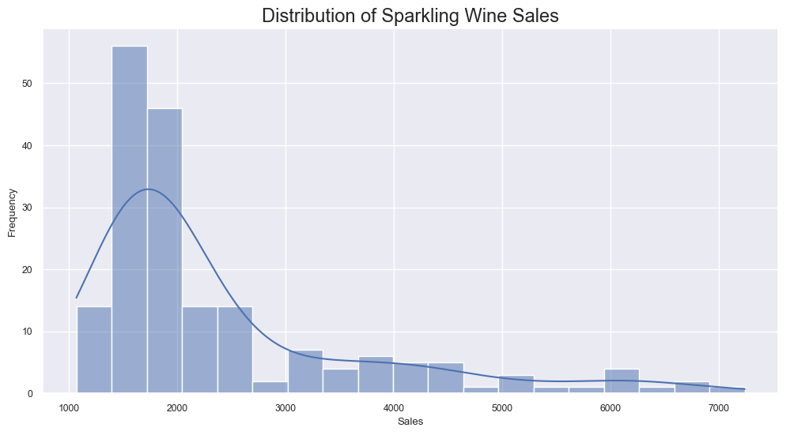

```python
# Display Histplot to view distribution of Sparkling Wine Sales
sns.histplot(df_sparkling['Sparkling'], kde=True)
plt.title('Distribution of Sparkling Wine Sales', fontsize=17)
plt.xlabel('Sales')
plt.ylabel('Frequency')
plt.show()
```

##### Observations:

- Sparkling wine sales distribution show right-skewed histplot.
- Distribution plot show that form most periods sales are under 2,000.

#### Year and Month Statistics:

```python
# Display the first and last dates
print(f'First Date: {df_sparkling.index.min()}')
print(f'Last Date: {df_sparkling.index.max()}')
```

```
First Date: 1980-01-31 00:00:00
Last Date: 1995-07-31 00:00:00
```

```python
# Display Unique Years
df_sparkling.index.year.unique()
```

```
Index([1980, 1981, 1982, 1983, 1984, 1985, 1986, 1987, 1988, 1989, 1990, 1991,
       1992, 1993, 1994, 1995],
      dtype='int32', name='YearMonthDate')
```

##### Observations:

- The records start on Jan-1980 and the last record captured was for the momth Jul-1995.
- For the final year, data was not captured for the whole year.

### Bivariate Analysis

#### Time Plot

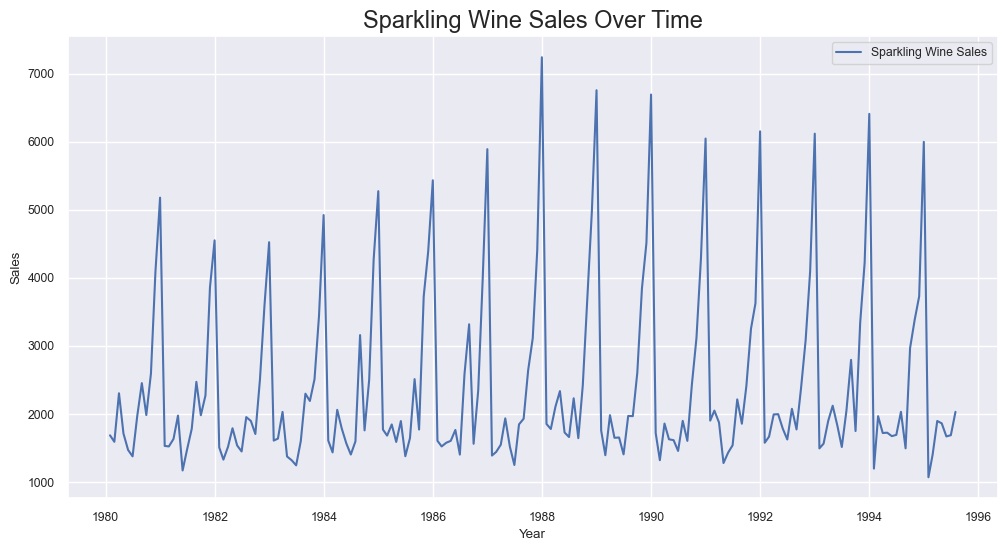

```python
# Plotting Sparkling Wine Sales over time
plt.plot(df_sparkling.index, df_sparkling['Sparkling'], label='Sparkling Wine Sales')
plt.xlabel('Year')
plt.ylabel('Sales')
plt.title('Sparkling Wine Sales Over Time',fontsize=17)
plt.legend()
plt.show()
```

##### Observations:

- Time plots moderate trend and clear seasonality withing the year.

#### Pivot Table - Sparkling Sales Trend by Year Grouped by Month

| YearMonthDate | January | February | March | April | May | June | July | August | September | October | November | December |
| --- | --- | --- | --- | --- | --- | --- | --- | --- | --- | --- | --- | --- |
| 1980 | 1686.0000 | 1591.0000 | 2304.0000 | 1712.0000 | 1471.0000 | 1377.0000 | 1966.0000 | 2453.0000 | 1984.0000 | 2596.0000 | 4087.0000 | 5179.0000 |
| 1981 | 1530.0000 | 1523.0000 | 1633.0000 | 1976.0000 | 1170.0000 | 1480.0000 | 1781.0000 | 2472.0000 | 1981.0000 | 2273.0000 | 3857.0000 | 4551.0000 |
| 1982 | 1510.0000 | 1329.0000 | 1518.0000 | 1790.0000 | 1537.0000 | 1449.0000 | 1954.0000 | 1897.0000 | 1706.0000 | 2514.0000 | 3593.0000 | 4524.0000 |
| 1983 | 1609.0000 | 1638.0000 | 2030.0000 | 1375.0000 | 1320.0000 | 1245.0000 | 1600.0000 | 2298.0000 | 2191.0000 | 2511.0000 | 3440.0000 | 4923.0000 |
| 1984 | 1609.0000 | 1435.0000 | 2061.0000 | 1789.0000 | 1567.0000 | 1404.0000 | 1597.0000 | 3159.0000 | 1759.0000 | 2504.0000 | 4273.0000 | 5274.0000 |
| 1985 | 1771.0000 | 1682.0000 | 1846.0000 | 1589.0000 | 1896.0000 | 1379.0000 | 1645.0000 | 2512.0000 | 1771.0000 | 3727.0000 | 4388.0000 | 5434.0000 |
| 1986 | 1606.0000 | 1523.0000 | 1577.0000 | 1605.0000 | 1765.0000 | 1403.0000 | 2584.0000 | 3318.0000 | 1562.0000 | 2349.0000 | 3987.0000 | 5891.0000 |
| 1987 | 1389.0000 | 1442.0000 | 1548.0000 | 1935.0000 | 1518.0000 | 1250.0000 | 1847.0000 | 1930.0000 | 2638.0000 | 3114.0000 | 4405.0000 | 7242.0000 |
| 1988 | 1853.0000 | 1779.0000 | 2108.0000 | 2336.0000 | 1728.0000 | 1661.0000 | 2230.0000 | 1645.0000 | 2421.0000 | 3740.0000 | 4988.0000 | 6757.0000 |
| 1989 | 1757.0000 | 1394.0000 | 1982.0000 | 1650.0000 | 1654.0000 | 1406.0000 | 1971.0000 | 1968.0000 | 2608.0000 | 3845.0000 | 4514.0000 | 6694.0000 |
| 1990 | 1720.0000 | 1321.0000 | 1859.0000 | 1628.0000 | 1615.0000 | 1457.0000 | 1899.0000 | 1605.0000 | 2424.0000 | 3116.0000 | 4286.0000 | 6047.0000 |
| 1991 | 1902.0000 | 2049.0000 | 1874.0000 | 1279.0000 | 1432.0000 | 1540.0000 | 2214.0000 | 1857.0000 | 2408.0000 | 3252.0000 | 3627.0000 | 6153.0000 |
| 1992 | 1577.0000 | 1667.0000 | 1993.0000 | 1997.0000 | 1783.0000 | 1625.0000 | 2076.0000 | 1773.0000 | 2377.0000 | 3088.0000 | 4096.0000 | 6119.0000 |
| 1993 | 1494.0000 | 1564.0000 | 1898.0000 | 2121.0000 | 1831.0000 | 1515.0000 | 2048.0000 | 2795.0000 | 1749.0000 | 3339.0000 | 4227.0000 | 6410.0000 |
| 1994 | 1197.0000 | 1968.0000 | 1720.0000 | 1725.0000 | 1674.0000 | 1693.0000 | 2031.0000 | 1495.0000 | 2968.0000 | 3385.0000 | 3729.0000 | 5999.0000 |
| 1995 | 1070.0000 | 1402.0000 | 1897.0000 | 1862.0000 | 1670.0000 | 1688.0000 | 2031.0000 | NaN | NaN | NaN | NaN | NaN |

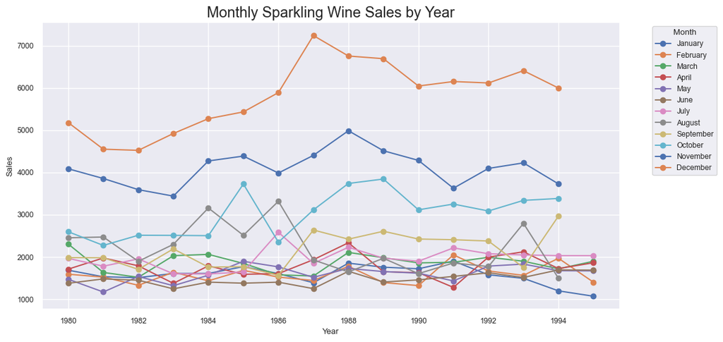

```python
# Create pivot table with Index as Year and Columns as Month
pivot_table_ym = df_sparkling.pivot_table(
    values='Sparkling',
    index=df_sparkling.index.year,
    columns=df_sparkling.index.month,
    aggfunc='sum'
)

# Map month numbers to month names in the correct order
month_names = ['January', 'February', 'March', 'April', 'May', 'June',
               'July', 'August', 'September', 'October', 'November', 'December']
pivot_table_ym.columns = month_names

# Sort columns by the custom month order
pivot_table_ym = pivot_table_ym[month_names]

# Display pivot table
display(pivot_table_ym)

# Plot the pivot table
pivot_table_ym.plot(kind='line', marker='o')
plt.title('Monthly Sparkling Wine Sales by Year', fontsize=17)
plt.xlabel('Year')
plt.ylabel('Sales')
plt.legend(title='Month', bbox_to_anchor=(1.05, 1), loc='upper left')
plt.show()
```

##### Observations:

- Year on Year sales for Sparkling wine deviate consistently.
- Wine sales show incremental trend till late 1980s, after which stabilize.
- There is clear spike in sales past October, peaking in December.

#### Pivot Table and Chart - Sales Trend by Month Grouped by Year

| YearMonthDate | 1980 | 1981 | 1982 | 1983 | 1984 | 1985 | 1986 | 1987 | 1988 | 1989 | 1990 | 1991 | 1992 | 1993 | 1994 | 1995 |
| --- | --- | --- | --- | --- | --- | --- | --- | --- | --- | --- | --- | --- | --- | --- | --- | --- |
| January | 1686.0000 | 1530.0000 | 1510.0000 | 1609.0000 | 1609.0000 | 1771.0000 | 1606.0000 | 1389.0000 | 1853.0000 | 1757.0000 | 1720.0000 | 1902.0000 | 1577.0000 | 1494.0000 | 1197.0000 | 1070.0000 |
| February | 1591.0000 | 1523.0000 | 1329.0000 | 1638.0000 | 1435.0000 | 1682.0000 | 1523.0000 | 1442.0000 | 1779.0000 | 1394.0000 | 1321.0000 | 2049.0000 | 1667.0000 | 1564.0000 | 1968.0000 | 1402.0000 |
| March | 2304.0000 | 1633.0000 | 1518.0000 | 2030.0000 | 2061.0000 | 1846.0000 | 1577.0000 | 1548.0000 | 2108.0000 | 1982.0000 | 1859.0000 | 1874.0000 | 1993.0000 | 1898.0000 | 1720.0000 | 1897.0000 |
| April | 1712.0000 | 1976.0000 | 1790.0000 | 1375.0000 | 1789.0000 | 1589.0000 | 1605.0000 | 1935.0000 | 2336.0000 | 1650.0000 | 1628.0000 | 1279.0000 | 1997.0000 | 2121.0000 | 1725.0000 | 1862.0000 |
| May | 1471.0000 | 1170.0000 | 1537.0000 | 1320.0000 | 1567.0000 | 1896.0000 | 1765.0000 | 1518.0000 | 1728.0000 | 1654.0000 | 1615.0000 | 1432.0000 | 1783.0000 | 1831.0000 | 1674.0000 | 1670.0000 |
| June | 1377.0000 | 1480.0000 | 1449.0000 | 1245.0000 | 1404.0000 | 1379.0000 | 1403.0000 | 1250.0000 | 1661.0000 | 1406.0000 | 1457.0000 | 1540.0000 | 1625.0000 | 1515.0000 | 1693.0000 | 1688.0000 |
| July | 1966.0000 | 1781.0000 | 1954.0000 | 1600.0000 | 1597.0000 | 1645.0000 | 2584.0000 | 1847.0000 | 2230.0000 | 1971.0000 | 1899.0000 | 2214.0000 | 2076.0000 | 2048.0000 | 2031.0000 | 2031.0000 |
| August | 2453.0000 | 2472.0000 | 1897.0000 | 2298.0000 | 3159.0000 | 2512.0000 | 3318.0000 | 1930.0000 | 1645.0000 | 1968.0000 | 1605.0000 | 1857.0000 | 1773.0000 | 2795.0000 | 1495.0000 | NaN |
| September | 1984.0000 | 1981.0000 | 1706.0000 | 2191.0000 | 1759.0000 | 1771.0000 | 1562.0000 | 2638.0000 | 2421.0000 | 2608.0000 | 2424.0000 | 2408.0000 | 2377.0000 | 1749.0000 | 2968.0000 | NaN |
| October | 2596.0000 | 2273.0000 | 2514.0000 | 2511.0000 | 2504.0000 | 3727.0000 | 2349.0000 | 3114.0000 | 3740.0000 | 3845.0000 | 3116.0000 | 3252.0000 | 3088.0000 | 3339.0000 | 3385.0000 | NaN |
| November | 4087.0000 | 3857.0000 | 3593.0000 | 3440.0000 | 4273.0000 | 4388.0000 | 3987.0000 | 4405.0000 | 4988.0000 | 4514.0000 | 4286.0000 | 3627.0000 | 4096.0000 | 4227.0000 | 3729.0000 | NaN |
| December | 5179.0000 | 4551.0000 | 4524.0000 | 4923.0000 | 5274.0000 | 5434.0000 | 5891.0000 | 7242.0000 | 6757.0000 | 6694.0000 | 6047.0000 | 6153.0000 | 6119.0000 | 6410.0000 | 5999.0000 | NaN |

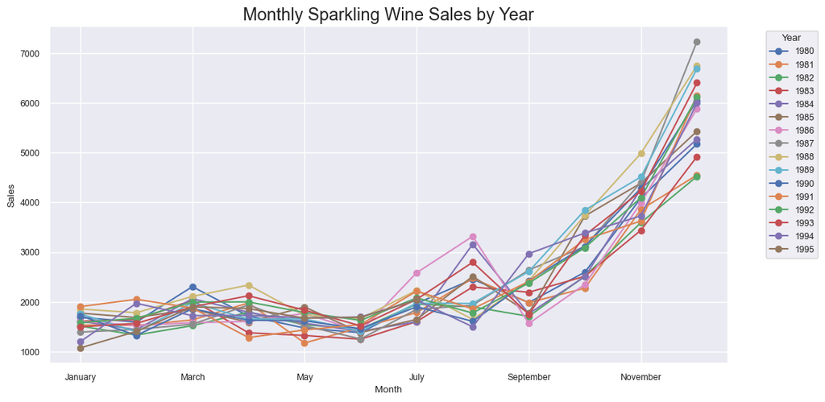

```python
# Create pivot table
pivot_table_my = df_sparkling.pivot_table(
    values='Sparkling',
    index=df_sparkling.index.month_name(),
    columns=df_sparkling.index.year,
    aggfunc='sum'
)

# Ensure the months are in the correct order
month_order = ['January', 'February', 'March', 'April', 'May', 'June', 'July', 'August', 'September', 'October', 'November', 'December']
pivot_table_my = pivot_table_my.reindex(month_order)

# Display pivot table
display(pivot_table_my)

# Plot the pivot table
pivot_table_my.plot(kind='line', marker='o')
plt.title('Monthly Sparkling Wine Sales by Year', fontsize=17)
plt.xlabel('Month')
plt.ylabel('Sales')
plt.legend(title='Year', bbox_to_anchor=(1.05, 1), loc='upper left')
plt.show()
```

#### Seasonal Subseries Box Plot

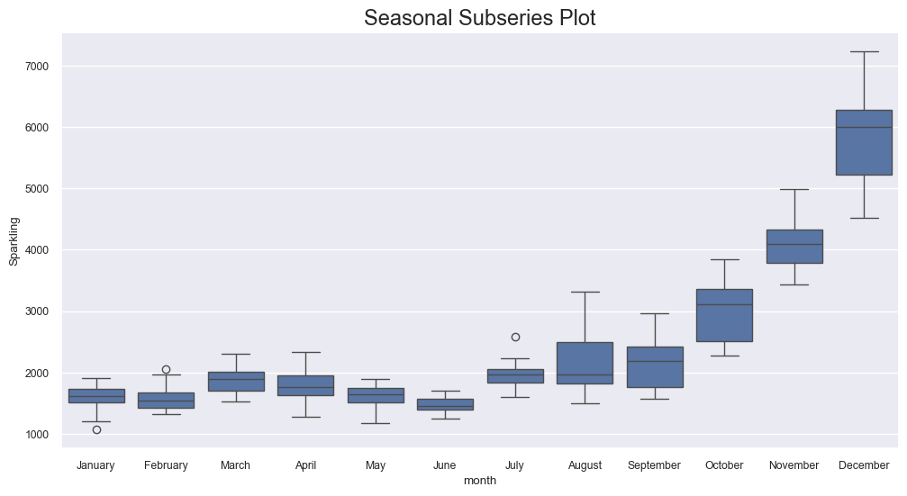

```python
# Create a seasonal subseries plot by Month
df_sparkling['month'] = df_sparkling.index.month_name()
sns.boxplot(x='month', y='Sparkling', data=df_sparkling)
plt.title('Seasonal Subseries Plot', fontsize=17)
plt.show()
```

##### Observations:

- Sales seems to be taking momentum post July.
- December, November and October are the top revenue contributing momths.
- Some outliers in January, February and July.

#### Year-on-Year Trend and Outlier Detection Box Plot

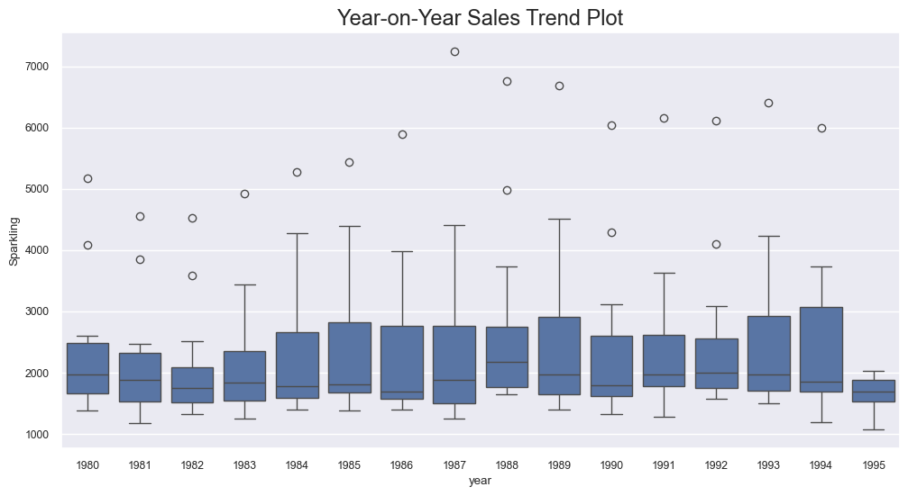

```python
# Create a seasonal subseries plot by Year
df_sparkling['year'] = df_sparkling.index.year
sns.boxplot(x='year', y='Sparkling', data=df_sparkling)
plt.title('Year-on-Year Sales Trend Plot', fontsize=17)
plt.show()
```

##### Observations:

- Most years show median sales of 2000 and less.
- Almost every year shows upper outliers.

#### Moving Averages

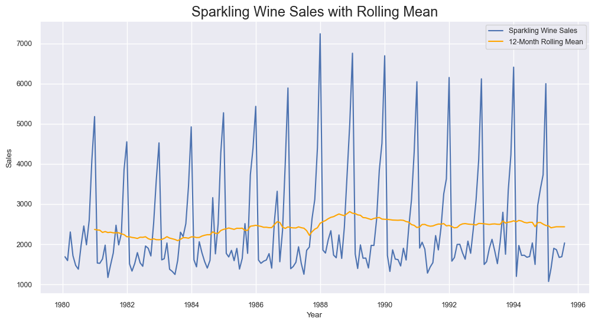

```python
# Calculate moving averages
df_sparkling['Rolling_Mean'] = df_sparkling['Sparkling'].rolling(window=12).mean()

# Plot the rolling mean
plt.plot(df_sparkling['Sparkling'], label='Sparkling Wine Sales')
plt.plot(df_sparkling['Rolling_Mean'], label='12-Month Rolling Mean', color='orange')
plt.xlabel('Year')
plt.ylabel('Sales')
plt.title('Sparkling Wine Sales with Rolling Mean', fontsize=17)
plt.legend()
plt.show()
```

##### Observations:

- The 12-month rolling mean shows a slight increase in the late-1980s, indicating a period of growth in sales, followed by a more stable trend towards the early 1990s.
- Despite short-term variations and occasional dips, the overall pattern remains consistent year over year, with noticeable seasonal spikes, suggesting sales are heavily influenced by predictable events such as holiday celebrations.

### Decomposition:

#### Testing for Additive Decomposition Assumption

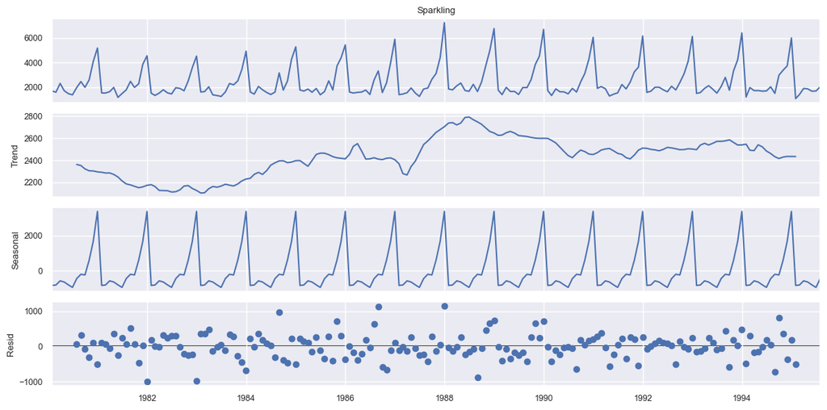

```python
# Decompose the time series
additive_decompose_result = seasonal_decompose(df_sparkling['Sparkling'], model='additive')
additive_decompose_result.plot()
plt.show()
```

```python
# Additive Decomposition
trend = additive_decompose_result.trend
seasonality = additive_decompose_result.seasonal
residual = additive_decompose_result.resid

print('Additive: Trend, Seasonality and Residuals')
tsr_df = pd.concat([trend,seasonality,residual], axis=1)
display(tsr_df.head(12))
```

```
Additive: Trend, Seasonality and Residuals
```

| YearMonthDate | trend | seasonal | resid |
| --- | --- | --- | --- |
| 1980-01-31 | NaN | -854.2606 | NaN |
| 1980-02-29 | NaN | -830.3507 | NaN |
| 1980-03-31 | NaN | -592.3566 | NaN |
| 1980-04-30 | NaN | -658.4906 | NaN |
| 1980-05-31 | NaN | -824.4162 | NaN |
| 1980-06-30 | NaN | -967.4340 | NaN |
| 1980-07-31 | 2360.6667 | -465.5023 | 70.8356 |
| 1980-08-31 | 2351.3333 | -214.3328 | 315.9995 |
| 1980-09-30 | 2320.5417 | -254.6773 | -81.8644 |
| 1980-10-31 | 2303.5833 | 599.7700 | -307.3533 |
| 1980-11-30 | 2302.0417 | 1675.0672 | 109.8912 |
| 1980-12-31 | 2293.7917 | 3386.9838 | -501.7755 |

```
Residual Mean = -1.2088458994707585
```

```
ShapiroResult(statistic=0.9833056372432118, pvalue=0.03433683203799767)
```

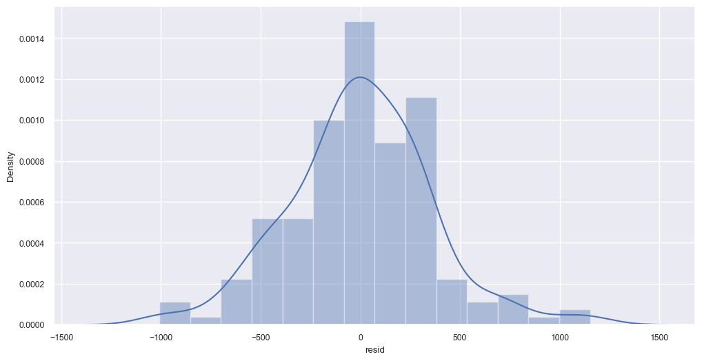

```python
# Checking for Additive Decomposition Assumptions
print(f'Residual Mean = {residual.mean()}')
from scipy.stats import shapiro
sns.distplot(residual)
shapiro(residual.dropna())
```

#### Testing for Multiplicative Decomposition Assumption

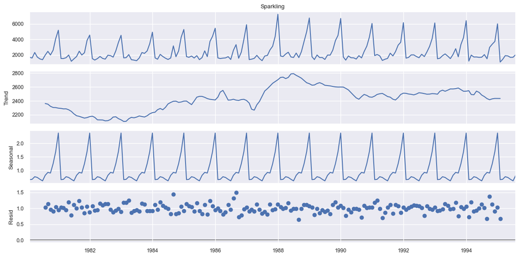

```python
# Decompose the time series
mult_decompose_result = seasonal_decompose(df_sparkling['Sparkling'], model='multiplicative')
mult_decompose_result.plot()
plt.show()
```

```python
# Multiplicative Decomposition
m_trend = mult_decompose_result.trend
m_seasonality = mult_decompose_result.seasonal
m_residual = mult_decompose_result.resid

print('Multiplicative: Trend, Seasonality and Residuals:')
m_tsr_df = pd.concat([m_trend,m_seasonality,m_residual], axis=1)
display(m_tsr_df.head(12))
```

```
Multiplicative: Trend, Seasonality and Residuals:
```

| YearMonthDate | trend | seasonal | resid |
| --- | --- | --- | --- |
| 1980-01-31 | NaN | 0.6498 | NaN |
| 1980-02-29 | NaN | 0.6592 | NaN |
| 1980-03-31 | NaN | 0.7574 | NaN |
| 1980-04-30 | NaN | 0.7304 | NaN |
| 1980-05-31 | NaN | 0.6606 | NaN |
| 1980-06-30 | NaN | 0.6035 | NaN |
| 1980-07-31 | 2360.6667 | 0.8092 | 1.0292 |
| 1980-08-31 | 2351.3333 | 0.9188 | 1.1354 |
| 1980-09-30 | 2320.5417 | 0.8944 | 0.9560 |
| 1980-10-31 | 2303.5833 | 1.2418 | 0.9075 |
| 1980-11-30 | 2302.0417 | 1.6902 | 1.0504 |
| 1980-12-31 | 2293.7917 | 2.3848 | 0.9468 |

```
Residual Mean = 0.9997456359115033
```

```
ShapiroResult(statistic=0.9859993833004659, pvalue=0.07803310394787422)
```

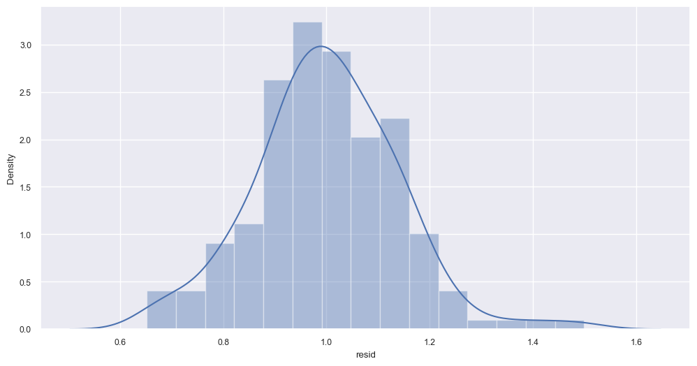

```python
# Checking for Multiplicative Decomposition Assumptions
print(f'Residual Mean = {m_residual.mean()}')
from scipy.stats import shapiro
sns.distplot(m_residual)
shapiro(m_residual.dropna())
```

##### Observations:

- The residuals are evenly distributed around 1 and the histogram indicates that they follow an approximate normal distribution, validating the assumptions for the multiplicative decomposition.
- The assumption of normality is also supported by Shapiro-Wilk test, with p-value of 0.078 we fail to reject the null-hypothesis.

### EDA Observations:

**Overall Trends:**

- Sales data shows a moderate upward trend with clear seasonality, peaking in December each year.
- The 12-month rolling mean indicates growth until the late 1980s, followed by stability.

**Monthly and Yearly Trends:**

**Seasonal and Outlier Analysis:**

- Seasonal patterns show highest sales in October, November, and December.
- Outliers are present in January, February, and July, indicating occasional deviations from normal sales patterns.

## Data Preparation for Modeling

```python
# Identify unique values in Years
df_sparkling.index.year.unique()
```

```
Index([1980, 1981, 1982, 1983, 1984, 1985, 1986, 1987, 1988, 1989, 1990, 1991,
       1992, 1993, 1994, 1995],
      dtype='int32', name='YearMonthDate')
```

- Observations include dates from 1980 to 1995.

```python
# Exclude columns other than Sparkling Sales Data and create a new dataframe
df_sparkling_sales = df_sparkling[['Sparkling']].copy()
df_sparkling_sales.head()
```

| YearMonthDate | Sparkling |
| --- | --- |
| 1980-01-31 | 1686 |
| 1980-02-29 | 1591 |
| 1980-03-31 | 2304 |
| 1980-04-30 | 1712 |
| 1980-05-31 | 1471 |

```python
# Split data in training and test sets
train_dfs = df_sparkling_sales[df_sparkling_sales.index <= '1991']
test_dfs = df_sparkling_sales[df_sparkling_sales.index > '1991']
print(f'Train Dataset Shape: {train_dfs.shape}')
print(f'Test Dataset Shape: {test_dfs.shape}')
```

```
Train Dataset Shape: (132, 1)
Test Dataset Shape: (55, 1)
```

```python
# Display top 5 rows of Train and Test Datasets
print("Training Dataset:")
display(train_dfs.head())
print("\nTest Dataset:")
display(test_dfs.head())
```

```
Training Dataset:
```

| YearMonthDate | Sparkling |
| --- | --- |
| 1980-01-31 | 1686 |
| 1980-02-29 | 1591 |
| 1980-03-31 | 2304 |
| 1980-04-30 | 1712 |
| 1980-05-31 | 1471 |

```
Test Dataset:
```

| YearMonthDate | Sparkling |
| --- | --- |
| 1991-01-31 | 1902 |
| 1991-02-28 | 2049 |
| 1991-03-31 | 1874 |
| 1991-04-30 | 1279 |
| 1991-05-31 | 1432 |

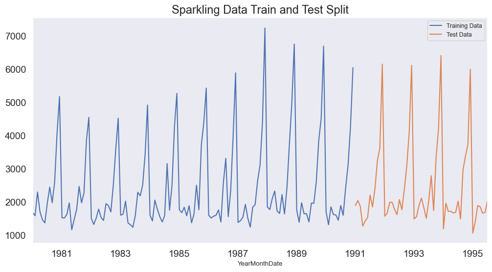

```python
# Train and Test Split Time Series Plot

train_dfs['Sparkling'].plot(fontsize=14)
test_dfs['Sparkling'].plot(fontsize=14)
plt.grid()
plt.legend(['Training Data','Test Data'])
plt.title('Sparkling Data Train and Test Split', fontsize=17)
plt.savefig('spark_split_ts.jpg', bbox_inches='tight')
plt.show()
```

## Model Building

- Model 1: Linear Regression Model
- Model 2: Naive Approach Model
- Model 3: Simple Average Model
- Model 4: Single Exponential Smoothing (SES) Model
- Model 5: Double Exponential Smoothing (DES) or Holt's Model
- Model 6: Triple Exponential Smoothing (TES) or Holt-Winter's Model
- Stationarity Check
- Model 7: Automated ARIMA Model
- Model 8: Automated SARIMA Model

### Linear Regression Model

```python
# Create time indices for the training and testing datasets
train_time = [i+1 for i in range(len(train_dfs))]
test_time = [i+133 for i in range(len(test_dfs))]

# Print the time indices
print('Training Time Instance :','\n',train_time)
print('Test Time Instance :','\n',test_time)
```

```
Training Time Instance :
 [1, 2, 3, 4, 5, 6, 7, 8, 9, 10, 11, 12, 13, 14, 15, 16, 17, 18, 19, 20, 21, 22, 23, 24, 25, 26, 27, 28, 29, 30, 31, 32, 33, 34, 35, 36, 37, 38, 39, 40, 41, 42, 43, 44, 45, 46, 47, 48, 49, 50, 51, 52, 53, 54, 55, 56, 57, 58, 59, 60, 61, 62, 63, 64, 65, 66, 67, 68, 69, 70, 71, 72, 73, 74, 75, 76, 77,…
Test Time Instance :
 [133, 134, 135, 136, 137, 138, 139, 140, 141, 142, 143, 144, 145, 146, 147, 148, 149, 150, 151, 152, 153, 154, 155, 156, 157, 158, 159, 160, 161, 162, 163, 164, 165, 166, 167, 168, 169, 170, 171, 172, 173, 174, 175, 176, 177, 178, 179, 180, 181, 182, 183, 184, 185, 186, 187]
```

```python
# Prepare Dataset for LinearRegression
lr_train_dfs = train_dfs.copy()
lr_test_dfs = test_dfs.copy()

# Add time indices to the dataframe
lr_train_dfs['time'] = train_time
lr_test_dfs['time'] = test_time

# Print lR train and test sets.
print("LinearRegression Train Set:")
display(lr_train_dfs.head())
print("\nLinearRegression Test Set:")
display(lr_test_dfs.head())
```

```
LinearRegression Train Set:
```

| YearMonthDate | Sparkling | time |
| --- | --- | --- |
| 1980-01-31 | 1686 | 1 |
| 1980-02-29 | 1591 | 2 |
| 1980-03-31 | 2304 | 3 |
| 1980-04-30 | 1712 | 4 |
| 1980-05-31 | 1471 | 5 |

```
LinearRegression Test Set:
```

| YearMonthDate | Sparkling | time |
| --- | --- | --- |
| 1991-01-31 | 1902 | 133 |
| 1991-02-28 | 2049 | 134 |
| 1991-03-31 | 1874 | 135 |
| 1991-04-30 | 1279 | 136 |
| 1991-05-31 | 1432 | 137 |

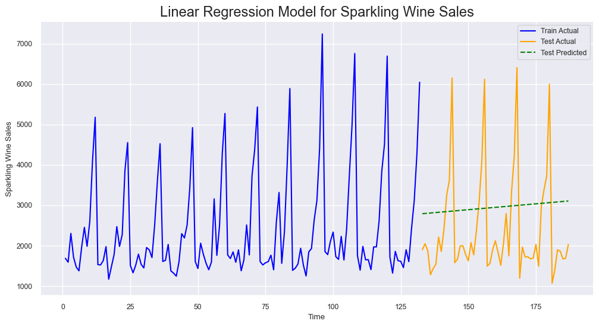

```python
# Now that our dataset is ready, we will build and fit the LinearRegression Model
lr = LinearRegression()
lr.fit(lr_train_dfs[['time']],lr_train_dfs['Sparkling'])

# Predict on training and testing data
train_predictions = lr.predict(lr_train_dfs[['time']])
test_predictions = lr.predict(lr_test_dfs[['time']])

# Plot the actual and predicted values

# Plot test data
plt.plot(lr_train_dfs['time'], lr_train_dfs['Sparkling'], label='Train Actual', color='blue')
# Plot test data
plt.plot(lr_test_dfs['time'], lr_test_dfs['Sparkling'], label='Test Actual', color='orange')
# Plot predicted values for testing data
plt.plot(lr_test_dfs['time'], test_predictions, label='Test Predicted', linestyle='--', color='green')

# Add labels, title, and legend
plt.xlabel('Time')
plt.ylabel('Sparkling Wine Sales')
plt.title('Linear Regression Model for Sparkling Wine Sales',fontsize=17)
plt.legend()
plt.show()
```

```python
# Calculate Root Mean Squared Error for LinearRegression Model
rmse_lr_test = metrics.mean_squared_error(lr_test_dfs['Sparkling'],test_predictions,squared=False)
print(f'For RegressionOnTime forecast on the Test Data,  RMSE is {rmse_lr_test: .4f}')
```

```
For RegressionOnTime forecast on the Test Data,  RMSE is  1389.1352
```

```python
resultsDf = pd.DataFrame({'Test RMSE': [rmse_lr_test]},index=['Linear Regression'])
resultsDf
```

|  | Test RMSE |
| --- | --- |
| Linear Regression | 1389.1352 |

#### Observations:

- Linear Regression Model shows limited accuracy, some trend without seasonality.
- RMSE on test data is 1389.14 (rounded to 2 decimals).
- We will continue to test other models.

### Naive Approach Model

```python
# Create Train and Test Datasets for Naive Model
Naive_train = train_dfs.copy()
Naive_test = test_dfs.copy()

# Display bottom rows of train dataset and top rows of test dataset
print('Naive Train Dataset Last 5 Rows:')
display(Naive_train.tail())
print('\nNaive Test Dataset First 5 Rows:')
display(Naive_test.head())
```

```
Naive Train Dataset Last 5 Rows:
```

| YearMonthDate | Sparkling |
| --- | --- |
| 1990-08-31 | 1605 |
| 1990-09-30 | 2424 |
| 1990-10-31 | 3116 |
| 1990-11-30 | 4286 |
| 1990-12-31 | 6047 |

```
Naive Test Dataset First 5 Rows:
```

| YearMonthDate | Sparkling |
| --- | --- |
| 1991-01-31 | 1902 |
| 1991-02-28 | 2049 |
| 1991-03-31 | 1874 |
| 1991-04-30 | 1279 |
| 1991-05-31 | 1432 |

```python
# Add value for Naive Test Model
Naive_test['naive'] = np.asarray(train_dfs['Sparkling'])[len(np.asarray(train_dfs['Sparkling']))-1]
Naive_test.head()
```

| YearMonthDate | Sparkling | naive |
| --- | --- | --- |
| 1991-01-31 | 1902 | 6047 |
| 1991-02-28 | 2049 | 6047 |
| 1991-03-31 | 1874 | 6047 |
| 1991-04-30 | 1279 | 6047 |
| 1991-05-31 | 1432 | 6047 |

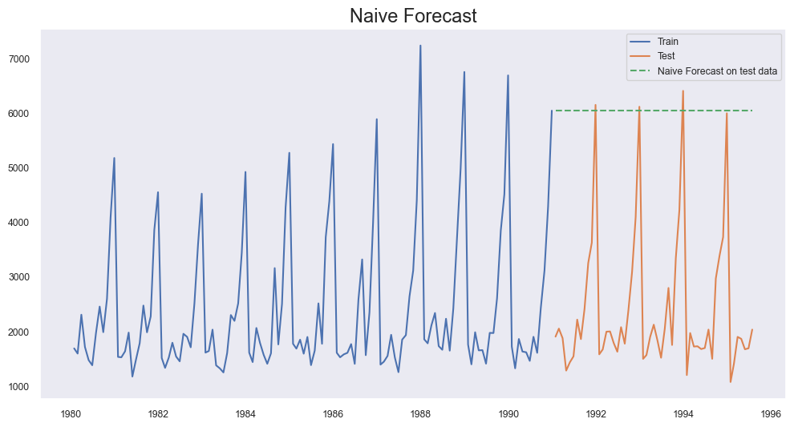

```python
# Plot Time Series Chart with Forecast using Naive Approach Model
plt.plot(Naive_train['Sparkling'],label='Train')
plt.plot(Naive_test['Sparkling'],label='Test')
plt.plot(Naive_test['naive'], linestyle='--', label='Naive Forecast on test data')
plt.legend(loc='best')
plt.title('Naive Forecast', fontsize=17)
plt.grid();
```

```python
# Calculate Root Mean Squared Error for Naive Approach Model Model
rmse_Naive_test = metrics.mean_squared_error(Naive_test['Sparkling'],Naive_test['naive'],squared=False)
print(f'For Naive Approach Model forecast on the Test Data,  RMSE is {rmse_Naive_test: .4f}')
```

```
For Naive Approach Model forecast on the Test Data,  RMSE is  3864.2794
```

```python
# Adding the new row to the DataFrame
resultsDf.loc['Naive Model'] = rmse_Naive_test
resultsDf
```

|  | Test RMSE |
| --- | --- |
| Linear Regression | 1389.1352 |
| Naive Model | 3864.2794 |

#### Observations:

- Naive Model doesn't show any improvements over Linear Regression Model
- We will progress to create forecast using Simple Average Model

### Simple Average Model

```python
# Create Train and Test Datasets for Simple Average Model
SimpleAverage_train = train_dfs.copy()
SimpleAverage_test = test_dfs.copy()

# Use Mean() to calculate forecast
SimpleAverage_test['mean_forecast'] = train_dfs['Sparkling'].mean()
SimpleAverage_test.head()
```

| YearMonthDate | Sparkling | mean_forecast |
| --- | --- | --- |
| 1991-01-31 | 1902 | 2403.7803 |
| 1991-02-28 | 2049 | 2403.7803 |
| 1991-03-31 | 1874 | 2403.7803 |
| 1991-04-30 | 1279 | 2403.7803 |
| 1991-05-31 | 1432 | 2403.7803 |

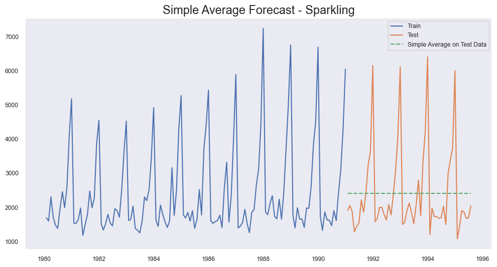

```python
# Plot Time Series Plot to Show Forecast using Simple Average Model
plt.plot(SimpleAverage_train['Sparkling'], label='Train')
plt.plot(SimpleAverage_test['Sparkling'], label='Test')

plt.plot(SimpleAverage_test['mean_forecast'], linestyle='--', label='Simple Average on Test Data')

plt.legend(loc='best')
plt.title("Simple Average Forecast - Sparkling", fontsize=17)
plt.grid();
```

```python
# Calculate Root Mean Squared Error for Simple Average Model
rmse_SimpleAverage_test = metrics.mean_squared_error(SimpleAverage_test['Sparkling'],SimpleAverage_test['mean_forecast'],squared=False)
print(f'For Simple Average Model forecast on the Test Data,  RMSE is {rmse_SimpleAverage_test: .4f}')
```

```
For Simple Average Model forecast on the Test Data,  RMSE is  1275.0818
```

```python
# Adding the new row to the DataFrame
resultsDf.loc['Simple Average Model'] = rmse_SimpleAverage_test
resultsDf
```

|  | Test RMSE |
| --- | --- |
| Linear Regression | 1389.1352 |
| Naive Model | 3864.2794 |
| Simple Average Model | 1275.0818 |

#### Observations:

- Simple Average Model shows a slight improvement over Linear Regression model, however both trend and seasonality is missing.
- We will explore various Exponetial Smoothing Methods next.

### Simple Exponential Smoothing (SES) Model

#### Auto-fit Simple Exponential Smoothing Model

```python
# Create train and test datasets for SES Model
SES_train = train_dfs.copy()
SES_test = test_dfs.copy()

# create class
SES_model = SimpleExpSmoothing(train_dfs)

# Fitting the Simple Exponential Smoothing model and asking python to choose the optimal parameters
SES_model_autofit = SES_model.fit(optimized=True)

# Let us check the parameters
SES_model_autofit.params
```

```
{'smoothing_level': 0.03953488372093023,
 'smoothing_trend': nan,
 'smoothing_seasonal': nan,
 'damping_trend': nan,
 'initial_level': 1686.0,
 'initial_trend': nan,
 'initial_seasons': array([], dtype=float64),
 'use_boxcox': False,
 'lamda': None,
 'remove_bias': False}
```

```python
# Create predicted values for SES model
SES_test['auto_predict'] = SES_model_autofit.forecast(steps=len(SES_test))
SES_test.head()
```

| YearMonthDate | Sparkling | auto_predict |
| --- | --- | --- |
| 1991-01-31 | 1902 | 2676.6764 |
| 1991-02-28 | 2049 | 2676.6764 |
| 1991-03-31 | 1874 | 2676.6764 |
| 1991-04-30 | 1279 | 2676.6764 |
| 1991-05-31 | 1432 | 2676.6764 |

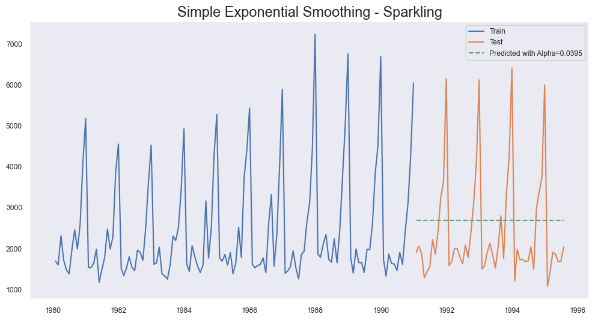

```python
# Plot chart showing train, test and predicted values using SES Model
plt.plot(SES_train['Sparkling'], label='Train')
plt.plot(SES_test['Sparkling'], label='Test')

plt.plot(SES_test['auto_predict'], linestyle='--', label='Predicted with Alpha=0.0395')

plt.legend(loc='best')
plt.title("Simple Exponential Smoothing - Sparkling", fontsize=17)
plt.grid();
```

```python
# Calculate Root Mean Squared Error for Simple Exponential Smoothing (SES)
rmse_SES_test = metrics.mean_squared_error(SES_test['Sparkling'],SES_test['auto_predict'],squared=False)
print(f'For Simple Exponential Smoothing Model forecast on the Test Data,  RMSE is {rmse_SES_test: .4f}')
```

```
For Simple Exponential Smoothing Model forecast on the Test Data,  RMSE is  1304.9274
```

```python
# Adding the new row to the DataFrame
resultsDf.loc['SES with Alpha=0.0395'] = rmse_SES_test
resultsDf
```

|  | Test RMSE |
| --- | --- |
| Linear Regression | 1389.1352 |
| Naive Model | 3864.2794 |
| Simple Average Model | 1275.0818 |
| SES with Alpha=0.0395 | 1304.9274 |

#### Tuned Simple Exponential Smoothing using different Alpha values

```python
# Define dataframe to store the results for various DES models
sesresults = pd.DataFrame({'Alpha Values':[],'Train RMSE':[],'Test RMSE': []})
sesresults
```

|  | Alpha Values | Train RMSE | Test RMSE |
| --- | --- | --- | --- |

```python
counter = 0
for i in np.arange(0.3,1,0.1):
    SES_model_alpha_i = SES_model.fit(smoothing_level=i,optimized=False,use_brute=True)
    SES_train['predict',i] = SES_model_alpha_i.fittedvalues
    SES_test['predict',i] = SES_model_alpha_i.forecast(steps=55)

    rmse_SES_model_train_i = metrics.mean_squared_error(SES_train['Sparkling'],SES_train['predict',i],squared=False)

    rmse_SES_model_test_i = metrics.mean_squared_error(SES_test['Sparkling'],SES_test['predict',i],squared=False)

    sesresults.loc[counter] = [i,rmse_SES_model_train_i,rmse_SES_model_test_i]
    counter += 1

# Display results of various SES models lowest Test RMSE first
sesresults.sort_values(by=['Test RMSE']).head()
```

|  | Alpha Values | Train RMSE | Test RMSE |
| --- | --- | --- | --- |
| 0 | 0.3000 | 1359.5117 | 1935.5071 |
| 1 | 0.4000 | 1352.5889 | 2311.9196 |
| 2 | 0.5000 | 1344.0044 | 2666.3514 |
| 3 | 0.6000 | 1338.8054 | 2979.2044 |
| 4 | 0.7000 | 1338.8443 | 3249.9441 |

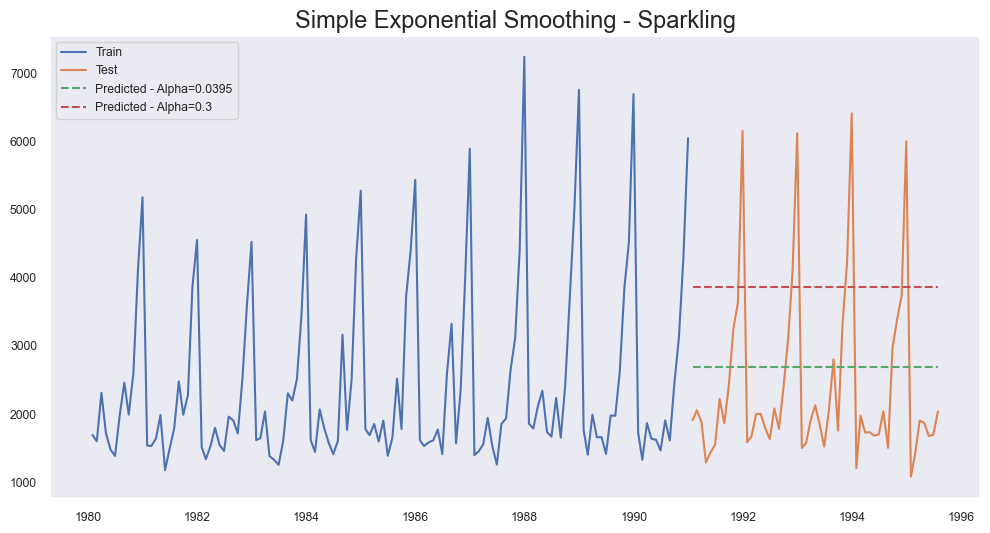

```python
# Plot chart showing train, test and predicted values using SES Model
plt.plot(SES_train['Sparkling'], label='Train')
plt.plot(SES_test['Sparkling'], label='Test')

plt.plot(SES_test['auto_predict'], linestyle='--', label='Predicted - Alpha=0.0395')
plt.plot(SES_test['predict', 0.3], linestyle='--', label='Predicted - Alpha=0.3')

plt.legend(loc='best')
plt.title("Simple Exponential Smoothing - Sparkling", fontsize=17)
plt.grid();
```

```python
# Adding the new row to the DataFrame
resultsDf.loc['Tuned SES with Alpha=0.3'] = '1935.5071'
resultsDf
```

|  | Test RMSE |
| --- | --- |
| Linear Regression | 1389.1352 |
| Naive Model | 3864.2794 |
| Simple Average Model | 1275.0818 |
| SES with Alpha=0.0395 | 1304.9274 |
| Tuned SES with Alpha=0.3 | 1935.5071 |

#### Observations:

- SES Model shows Test RMSE is 1304.93 (rounded) with alpha=0.0395.
- Tuned SES model with alpha=0.3 shows Test RMSE of 1935.51 (rounded).
- We will explore other Exponential Smoothing models.